# Deep Learning - aula 1

# Parte 1 - Parâmetros básicos

#### Garante que os resultados sejam reproduzíveis. Trata-se do valor utilizado para iniciar operações randômicas.

```r
set.seed(0)
```

# Parte 2 - Função de arquitetura

#### Vamos baixar nosso dataset

```r
#Lê nossos dados de vinho
data <- read.csv(file = "winequality-red.csv")

#Train Test Split
train_test_split_index <- 0.8 * nrow(data)

train <- data.frame(data[1:train_test_split_index,])
test <- data.frame(data[(train_test_split_index+1): nrow(data),])

#Padronizar dados para melhor performance
train_x <- data.frame(scale(train[1:11]))
train_y <- data.frame(scale(train[12]))

test_x <- data.frame(scale(test[1:11]))
test_y <- data.frame(scale(test[12]))

#transposição da matriz para facilitar
train_x <- t(train_x)
train_y <- t(train_y)

test_x <- t(test_x )
test_y <- t(test_y)
```

#### Função para criar arquitetura da rede

```r
getLayerSize <- function(X, y, hidden_neurons) {
  n_x <- dim(X)[1] #quantidade de linhas de x = neurônios da camada de entrada
  n_h <- hidden_neurons #quantidade de neurônios na camada escondida
  n_y <- dim(y)[1] #quantidade de linhas de y = neurônios da camada de saída

  size <- list("n_x" = n_x,
               "n_h" = n_h,
               "n_y" = n_y)

  return(size)
}
```

#### Aplica a função de criação de arquitetura

```r
layer_size <- getLayerSize(train_x, train_y, hidden_neurons = 4)
layer_size
```

```
## $n_x
## [1] 11
##
## $n_h
## [1] 4
##
## $n_y
## [1] 1
```

# Parte 3 - Inicializa Parâmetros randomicamente

```r
initializeParameters <- function(X, layer_size){

    n_x <- layer_size$n_x
    n_h <- layer_size$n_h
    n_y <- layer_size$n_y

    W1 <- matrix(runif(n_h * n_x), nrow = n_h, ncol = n_x, byrow = TRUE) * 0.01
    W2 <- matrix(runif(n_y * n_h), nrow = n_y, ncol = n_h, byrow = TRUE) * 0.01

    params <- list("W1" = W1,
                   "W2" = W2)

    return (params)
}
```

#### Aplica a função de inicializar pesos.

```r
init_params <- initializeParameters(train_x, layer_size)
lapply(init_params, function(x) dim(x))
```

```
## $W1
## [1]  4 11
##
## $W2
## [1] 1 4
```

# Parte 4 - Função Sigmoide

#### Função de ativação utilziada ao longo do nosso trabalho. Iremos fazer o arco tangente também, mas isso já temos função no R: tanh().

```r
sigmoid <- function(x){
    return(1 / (1 + exp(-x)))
}
```

# Parte 5 - Forward Propagation

#### Agora com todas as informações dos pesos e estrutura da rede, iniciamos o processo de geração de resultados. A multiplicação de matrizes será feita por meio do operador %*%.

```r
forwardPropagation <- function(X, params, layer_size){

    n_h <- layer_size$n_h
    n_y <- layer_size$n_y

    W1 <- params$W1
    W2 <- params$W2


    Z1 <- W1 %*% X
    A1 <- sigmoid(Z1)
    Z2 <- W2 %*% A1
    A2 <- sigmoid(Z2)

    cache <- list("Z1" = Z1,
                  "A1" = A1,
                  "Z2" = Z2,
                  "A2" = A2)

    return (cache)
}
```

# Parte 6 - Cost Function

```r
computeCost <- function(X, y, cache) {

    m <- dim(X)[2]

    A2 <- cache$A2

    cost <- sum((y-A2)^2)/m

    return (cost)
}
```

#### Aplica a função de forward propagation

```r
fwd_prop <- forwardPropagation(train_x, init_params, layer_size)
cost <- computeCost(train_x, train_y, fwd_prop)
```

# Parte 7 - Backpropagation

#### Essa parte exige conhecimento de cálculo diferencial para entender o gradiente. Entretanto, só irei dar a noção lógica do que está ocorrendo sem necessidade de adentrar no cálculo. Para mais detalhes vide: https://rpubs.com/theairbend3r/bin-classification-small-nnet-scratch-r.

```r
backwardPropagation <- function(X, y, cache, params, list_layer_size){

    m <- dim(X)[2]

    n_x <- list_layer_size$n_x
    n_h <- list_layer_size$n_h
    n_y <- list_layer_size$n_y

    A2 <- cache$A2
    A1 <- cache$A1
    W2 <- params$W2


    dZ2 <- A2 - y
    dW2 <- 1/m * (dZ2 %*% t(A1))


    dZ1 <- (t(W2) %*% dZ2) * (1 - A1^2)
    dW1 <- 1/m * (dZ1 %*% t(X))


    grads <- list("dW1" = dW1,
                  "dW2" = dW2)

    return(grads)
}
```

# Parte 8 - Atualiza pesos

#### A atualização de pesso é feita com base nos cálculos anteriores e na taxa de aprendizagem.

```r
updateParameters <- function(grads, params, learning_rate){

    W1 <- params$W1
    W2 <- params$W2

    dW1 <- grads$dW1
    dW2 <- grads$dW2


    W1 <- W1 - learning_rate * dW1
    W2 <- W2 - learning_rate * dW2

    updated_params <- list("W1" = W1,
                           "W2" = W2)

    return (updated_params)
}
```

# Parte 9 - Treina modelo

#### Quais as etapas?

- Arquitetura da rede.
- Inicializa um vetor de historia da função custo para guardar resultados.
- Faz foward loop.
- Calcula perda.
- Atualiza parâmetros.
- Usa os novos parâmetros.

##### Entra o conceitos de épocas (EPOCHS).

```r
trainModel <- function(X, y, num_iteration, hidden_neurons, lr){

    layer_size <- getLayerSize(X, y, hidden_neurons)
    init_params <- initializeParameters(X, layer_size)

    cost_history <- c()

    for (i in 1:num_iteration) {
        fwd_prop <- forwardPropagation(X, init_params, layer_size)
        cost <- computeCost(X, y, fwd_prop)
        back_prop <- backwardPropagation(X, y, fwd_prop, init_params, layer_size)
        update_params <- updateParameters(back_prop, init_params, learning_rate = lr)
        init_params <- update_params
        cost_history <- c(cost_history, cost)

    }

    model_out <- list("updated_params" = update_params,
                      "cost_hist" = cost_history)

    return (model_out)
}
```

#### Aplica o treinamento

```r
EPOCHS = 1000
HIDDEN_NEURONS = 40
LEARNING_RATE = 0.01

train_model <- trainModel(train_x, train_y, hidden_neurons = HIDDEN_NEURONS, num_iteration = EPOCHS, lr = LEARNING_RATE)
```

```r
makePrediction <- function(X, y, hidden_neurons){
    layer_size <- getLayerSize(X, y, hidden_neurons)
    params <- train_model$updated_params
    fwd_prop <- forwardPropagation(X, params, layer_size)
    pred <- fwd_prop$A2

    return (pred)
}
```

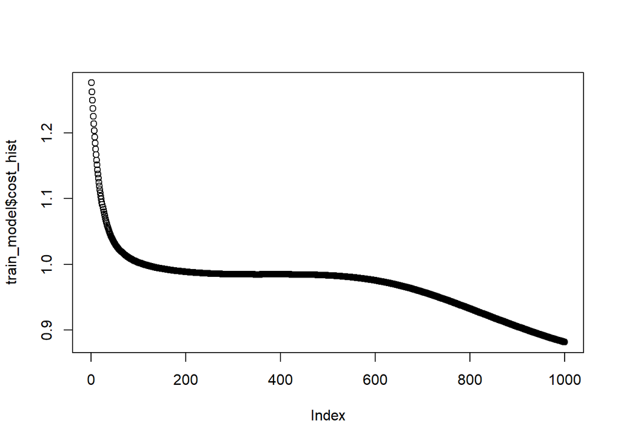

```r
y_pred <- makePrediction(test_x, test_y, HIDDEN_NEURONS)
compare <- rbind(y_pred,test_y)
plot(train_model$cost_hist)
```